# Project: Investigate a Dataset - [no show appointments]

- Introduction
- Data Wrangling
- Exploratory Data Analysis
- Conclusions

## Introduction

### Dataset Description

This dataset collects information from 100k medical appointments in Brazil and is focused on the question of whether or not patients show up for their appointment. A number of characteristics about the patient are included in each row.

● "ScheduledDay" tells us on what day the patient set up their appointment.

● "Neighborhood" indicates the location of the hospital.

● "Scholarship’ indicates whether or not the patient is enrolled in Brasilian welfare program "Bolsa Familia".

● "No-show" the last column: it says ‘No’ if the patient showed up to their appointment, and ‘Yes’ if they did not show up.

### Questions for Analysis

Q1: Does the patient scholarship effect on show up to their appointment?

Q2: Does the patient gender affect on show up to their appointment?

Q3: Does the patient age affect on show up to their appointment?

Q4: Does Neighbourhood affect on show up to their appointment?

```python
# Use this cell to set up import statements for all of the packages that you
#   plan to use.
import pandas as pd
import numpy as np
import matplotlib.pyplot as plt
import seaborn as sns

# Remember to include a 'magic word' so that your visualizations are plotted
#   inline with the notebook. See this page for more:
#   http://ipython.readthedocs.io/en/stable/interactive/magics.html
%matplotlib inline
```

## Data Wrangling

### General Properties

```python
# Load your data and print out a few lines. Perform operations to inspect data
#   types and look for instances of missing or possibly errant data.
df = pd.read_csv('noshowappointments-may-2016.csv')
df.head()
```

|  | PatientId | AppointmentID | Gender | ScheduledDay | AppointmentDay | Age | Neighbourhood | Scholarship | Hipertension | Diabetes | Alcoholism | Handcap | SMS_received | No-show |
| --- | --- | --- | --- | --- | --- | --- | --- | --- | --- | --- | --- | --- | --- | --- |
| 0 | 2.987250e+13 | 5642903 | F | 2016-04-29T18:38:08Z | 2016-04-29T00:00:00Z | 62 | JARDIM DA PENHA | 0 | 1 | 0 | 0 | 0 | 0 | No |
| 1 | 5.589978e+14 | 5642503 | M | 2016-04-29T16:08:27Z | 2016-04-29T00:00:00Z | 56 | JARDIM DA PENHA | 0 | 0 | 0 | 0 | 0 | 0 | No |
| 2 | 4.262962e+12 | 5642549 | F | 2016-04-29T16:19:04Z | 2016-04-29T00:00:00Z | 62 | MATA DA PRAIA | 0 | 0 | 0 | 0 | 0 | 0 | No |
| 3 | 8.679512e+11 | 5642828 | F | 2016-04-29T17:29:31Z | 2016-04-29T00:00:00Z | 8 | PONTAL DE CAMBURI | 0 | 0 | 0 | 0 | 0 | 0 | No |
| 4 | 8.841186e+12 | 5642494 | F | 2016-04-29T16:07:23Z | 2016-04-29T00:00:00Z | 56 | JARDIM DA PENHA | 0 | 1 | 1 | 0 | 0 | 0 | No |

```python
# view dimensions of dataset (rows, columns)
df.shape
```

```
(110527, 14)
```

```python
# view some informations of dataset
df.info()
```

```
<class 'pandas.core.frame.DataFrame'>
RangeIndex: 110527 entries, 0 to 110526
Data columns (total 14 columns):
 #   Column          Non-Null Count   Dtype
---  ------          --------------   -----
 0   PatientId       110527 non-null  float64
 1   AppointmentID   110527 non-null  int64
 2   Gender          110527 non-null  object
 3   ScheduledDay    110527 non-null  object
 4   AppointmentDay  110527 non-null  object
 5   Age             110527 non-null  int64
 6   Neighbourhood   110527 non-null  object
 7   Scholarship     110527 non-null  int64
 8   Hipertension    110527 non-null  int64
 9   Diabetes        110527 non-null  int64
 10  Alcoholism      110527 non-null  int64
 11  Handcap         110527 non-null  int64
 12  SMS_received    110527 non-null  int64
 13  No-show         110527 non-null  object
dtypes: float64(1), int64(8), object(5)
memory usage: 11.8+ MB
```

```python
# view null data
df.isnull().sum()
```

```
PatientId         0
AppointmentID     0
Gender            0
ScheduledDay      0
AppointmentDay    0
Age               0
Neighbourhood     0
Scholarship       0
Hipertension      0
Diabetes          0
Alcoholism        0
Handcap           0
SMS_received      0
No-show           0
dtype: int64
```

```python
# view duplicated data
df.duplicated().sum()
```

```
0
```

● 'ScheduledDay , AppointmentDay' are object not date

● Uncorrect spelling of ‘Hipertension’, ‘Handcap’ will rename

● The last column written as "No-show" will change to "Noshow"

● There is no missing or duplicated data

```python
# check some of statistics from dataset
df.describe()
```

|  | PatientId | AppointmentID | Age | Scholarship | Hipertension | Diabetes | Alcoholism | Handcap | SMS_received |
| --- | --- | --- | --- | --- | --- | --- | --- | --- | --- |
| count | 1.105270e+05 | 1.105270e+05 | 110527.000000 | 110527.000000 | 110527.000000 | 110527.000000 | 110527.000000 | 110527.000000 | 110527.000000 |
| mean | 1.474963e+14 | 5.675305e+06 | 37.088874 | 0.098266 | 0.197246 | 0.071865 | 0.030400 | 0.022248 | 0.321026 |
| std | 2.560949e+14 | 7.129575e+04 | 23.110205 | 0.297675 | 0.397921 | 0.258265 | 0.171686 | 0.161543 | 0.466873 |
| min | 3.921784e+04 | 5.030230e+06 | -1.000000 | 0.000000 | 0.000000 | 0.000000 | 0.000000 | 0.000000 | 0.000000 |
| 25% | 4.172614e+12 | 5.640286e+06 | 18.000000 | 0.000000 | 0.000000 | 0.000000 | 0.000000 | 0.000000 | 0.000000 |
| 50% | 3.173184e+13 | 5.680573e+06 | 37.000000 | 0.000000 | 0.000000 | 0.000000 | 0.000000 | 0.000000 | 0.000000 |
| 75% | 9.439172e+13 | 5.725524e+06 | 55.000000 | 0.000000 | 0.000000 | 0.000000 | 0.000000 | 0.000000 | 1.000000 |
| max | 9.999816e+14 | 5.790484e+06 | 115.000000 | 1.000000 | 1.000000 | 1.000000 | 1.000000 | 4.000000 | 1.000000 |

● Max. age is 115 years.

● Min. age is (-1) year it is may be uncorrect entry.

● Mean of age is 37 years.

### Data Cleaning

```python
# Convert 'ScheduledDay', 'AppointmentDay' to datetime type
df.ScheduledDay= pd.to_datetime(df.ScheduledDay)
df.AppointmentDay= pd.to_datetime(df.AppointmentDay)
```

```python
# confirm changes
df.info()
```

```
<class 'pandas.core.frame.DataFrame'>
RangeIndex: 110527 entries, 0 to 110526
Data columns (total 14 columns):
 #   Column          Non-Null Count   Dtype
---  ------          --------------   -----
 0   PatientId       110527 non-null  float64
 1   AppointmentID   110527 non-null  int64
 2   Gender          110527 non-null  object
 3   ScheduledDay    110527 non-null  datetime64[ns, UTC]
 4   AppointmentDay  110527 non-null  datetime64[ns, UTC]
 5   Age             110527 non-null  int64
 6   Neighbourhood   110527 non-null  object
 7   Scholarship     110527 non-null  int64
 8   Hipertension    110527 non-null  int64
 9   Diabetes        110527 non-null  int64
 10  Alcoholism      110527 non-null  int64
 11  Handcap         110527 non-null  int64
 12  SMS_received    110527 non-null  int64
 13  No-show         110527 non-null  object
dtypes: datetime64[ns, UTC](2), float64(1), int64(8), object(3)
memory usage: 11.8+ MB
```

```python
# Remove Age less than or equal Zero
df= df[df.Age >= 0]
```

```python
# confirm changes
df.shape
```

```
(110526, 14)
```

Only one patient has removed from dataset

```python
# Rename ‘Hipertension’, ‘Handcap’ , ‘No-show’ to 'Hypertension', ‘Handcap’, ‘No_show’
df.rename(columns={ 'Hipertension' : 'Hypertension'}, inplace=True)
df.rename(columns={ 'Handcap' : 'Handicap'}, inplace=True)
df.rename(columns={ 'No-show' : 'Noshow'}, inplace=True)
```

```python
# confirm changes
df.head()
```

|  | PatientId | AppointmentID | Gender | ScheduledDay | AppointmentDay | Age | Neighbourhood | Scholarship | Hypertension | Diabetes | Alcoholism | Handicap | SMS_received | Noshow |
| --- | --- | --- | --- | --- | --- | --- | --- | --- | --- | --- | --- | --- | --- | --- |
| 0 | 2.987250e+13 | 5642903 | F | 2016-04-29 18:38:08+00:00 | 2016-04-29 00:00:00+00:00 | 62 | JARDIM DA PENHA | 0 | 1 | 0 | 0 | 0 | 0 | No |
| 1 | 5.589978e+14 | 5642503 | M | 2016-04-29 16:08:27+00:00 | 2016-04-29 00:00:00+00:00 | 56 | JARDIM DA PENHA | 0 | 0 | 0 | 0 | 0 | 0 | No |
| 2 | 4.262962e+12 | 5642549 | F | 2016-04-29 16:19:04+00:00 | 2016-04-29 00:00:00+00:00 | 62 | MATA DA PRAIA | 0 | 0 | 0 | 0 | 0 | 0 | No |
| 3 | 8.679512e+11 | 5642828 | F | 2016-04-29 17:29:31+00:00 | 2016-04-29 00:00:00+00:00 | 8 | PONTAL DE CAMBURI | 0 | 0 | 0 | 0 | 0 | 0 | No |
| 4 | 8.841186e+12 | 5642494 | F | 2016-04-29 16:07:23+00:00 | 2016-04-29 00:00:00+00:00 | 56 | JARDIM DA PENHA | 0 | 1 | 1 | 0 | 0 | 0 | No |

```python
# Cleaning and dropping unnecessary data such as "AppointmentID", "ScheduledDay", "AppointmentDay"
df.drop([ "AppointmentID", "ScheduledDay", "AppointmentDay"], axis= 1, inplace= True)
```

```python
# confirm changes
df.head()
```

|  | PatientId | Gender | Age | Neighbourhood | Scholarship | Hypertension | Diabetes | Alcoholism | Handicap | SMS_received | Noshow |
| --- | --- | --- | --- | --- | --- | --- | --- | --- | --- | --- | --- |
| 0 | 2.987250e+13 | F | 62 | JARDIM DA PENHA | 0 | 1 | 0 | 0 | 0 | 0 | No |
| 1 | 5.589978e+14 | M | 56 | JARDIM DA PENHA | 0 | 0 | 0 | 0 | 0 | 0 | No |
| 2 | 4.262962e+12 | F | 62 | MATA DA PRAIA | 0 | 0 | 0 | 0 | 0 | 0 | No |
| 3 | 8.679512e+11 | F | 8 | PONTAL DE CAMBURI | 0 | 0 | 0 | 0 | 0 | 0 | No |
| 4 | 8.841186e+12 | F | 56 | JARDIM DA PENHA | 0 | 1 | 1 | 0 | 0 | 0 | No |

```python
# drop "PatientId" also
df.drop([ "PatientId"], axis= 1, inplace= True)
```

```python
# confirm changes
df.head()
```

|  | Gender | Age | Neighbourhood | Scholarship | Hypertension | Diabetes | Alcoholism | Handicap | SMS_received | Noshow |
| --- | --- | --- | --- | --- | --- | --- | --- | --- | --- | --- |
| 0 | F | 62 | JARDIM DA PENHA | 0 | 1 | 0 | 0 | 0 | 0 | No |
| 1 | M | 56 | JARDIM DA PENHA | 0 | 0 | 0 | 0 | 0 | 0 | No |
| 2 | F | 62 | MATA DA PRAIA | 0 | 0 | 0 | 0 | 0 | 0 | No |
| 3 | F | 8 | PONTAL DE CAMBURI | 0 | 0 | 0 | 0 | 0 | 0 | No |
| 4 | F | 56 | JARDIM DA PENHA | 0 | 1 | 1 | 0 | 0 | 0 | No |

## Exploratory Data Analysis

#### General Information about dataset

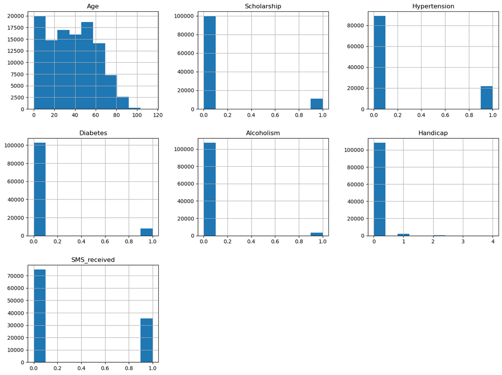

```python
df.hist(figsize=(16, 12));
```

The largest Number of patients age between 0 : 10 years.

No. of non scholarship patients is arround 100000.

according to diseases most of patients don't have chronic diseases.

Only 35000 patients SMS-received.

### Q1: Does the patient scholarship affect on show up to their appointment?

```python
df['Scholarship'].value_counts()
```

```
0    99665
1    10861
Name: Scholarship, dtype: int64
```

According to dataset only 10861 patients have Scholarship

& 99665 non Scholarship patients

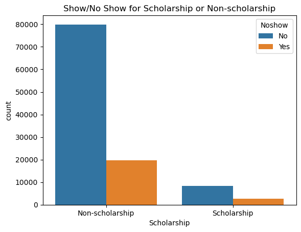

```python
schol= sns.countplot(x=df.Scholarship, hue= df.Noshow, data=df)
schol.set_title('Show/No Show for Scholarship or Non-scholarship')
x_ticks_labels=['Non-scholarship','Scholarship']
schol.set_xticklabels(x_ticks_labels)
plt.show()
```

but about 80000 non scholarship patient had attended, about 19500 non scholarship patient not attended yet.

Scholarship doesn't affect on show up to patients appointment

======================================================================================================================

### Q2: Does the patient gender affect on show up to their appointment?

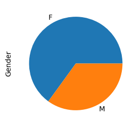

```python
df['Gender'].value_counts().plot(kind='pie', figsize=(3,3));
```

Total no. of Femals (71839)

Total no. of Males (38687)

```python
def f(zero, one):
  print("zero is reference for " + zero)
  print("one is reference for " + one)

f(zero = "Femal", one = "Male")
```

```
zero is reference for Femal
one is reference for Male
```

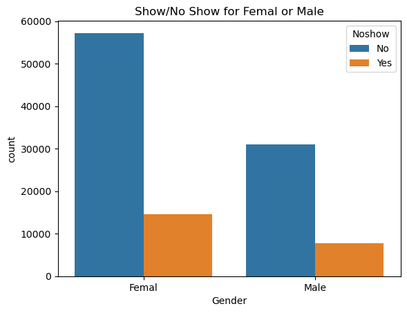

```python
Gend= sns.countplot(x=df.Gender, hue= df.Noshow, data=df)
Gend.set_title('Show/No Show for Femal or Male')
x_ticks_labels=['Femal','Male']
Gend.set_xticklabels(x_ticks_labels)
plt.show()
```

From above visualition only 15000 femal not attended from total no. 71839

Gender doesn't affect on show up to patients appointment

======================================================================================================================

### Q3: Does the patient age affect on show up to their appointment?

```python
df['Age'].value_counts()
```

```
0      3539
1      2273
52     1746
49     1652
53     1651
       ...
98        6
115       5
100       4
102       2
99        1
Name: Age, Length: 103, dtype: int64
```

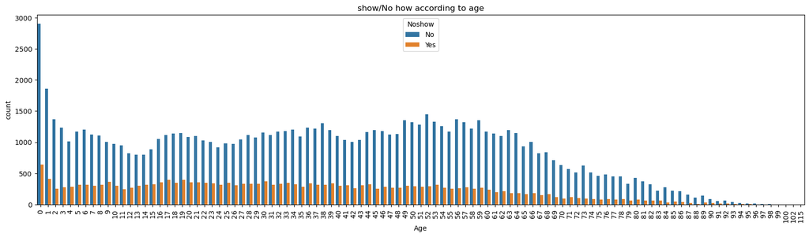

```python
plt.figure(figsize=(20,5))
plt.xticks(rotation=90)
age=sns.countplot(x=df.Age, hue= df.Noshow)
age.set_title("show/No how according to age")
plt.show()
```

======================================================================================================================

### Q4: Does sending sms affect on show up to their appointment?

```python
df['SMS_received'].value_counts()
```

```
0    75044
1    35482
Name: SMS_received, dtype: int64
```

According to count of sms recieved

Total No. of msg received 35482

Total No. of msg not received 75044

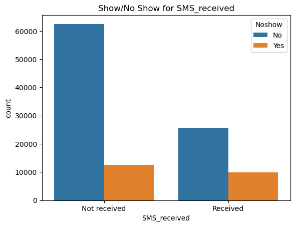

```python
SMS= sns.countplot(x=df.SMS_received, hue= df.Noshow, data=df)
SMS.set_title('Show/No Show for SMS_received')
x_ticks_labels=['Not received','Received']
SMS.set_xticklabels(x_ticks_labels)
plt.show()
```

Patients who don't received SMS and come are more in number than who do receive SMS

### Q4: Does Neighbourhood affect on show up to their appointment?

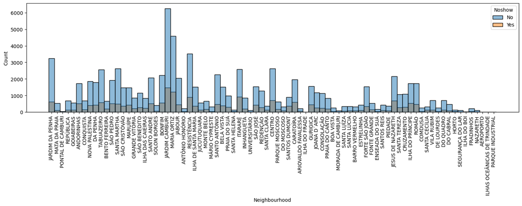

```python
plt.figure(figsize=(18,4))
plt.xticks(rotation=90)
nh= sns.histplot(x=df.Neighbourhood, data=df, hue=df.Noshow )
```

## Conclusions

● but notice that Neighbourhood It may have an impact on the attendance of patients, and this may be due to the quality of service provided in those clinics.

### Limitations

-There is no clearly relation between No show and other elements

```python
from subprocess import call
call(['python', '-m', 'nbconvert', 'Investigate_a_Dataset.ipynb'])
```

```
4294967295
```